# NLPAirlineTwitterJBasen

### Background and Context:

Twitter possesses 330 million monthly active users, which allows businesses to reach a broad population and connect with customers without intermediaries. On the other hand, there’s so much information that it’s difficult for brands to quickly detect negative social mentions that could harm their business.

That's why sentiment analysis/classification, which involves monitoring emotions in conversations on social media platforms, has become a key strategy in social media marketing.

Listening to how customers feel about the product/service on Twitter allows companies to understand their audience, keep on top of what’s being said about their brand and their competitors, and discover new trends in the industry.

#### Data Description:

A sentiment analysis job about the problems of each major U.S. airline. Twitter data was scraped from February of 2015 and contributors were asked to first classify positive, negative, and neutral tweets, followed by categorizing negative reasons (such as "late flight" or "rude service").

#### Dataset:

The dataset has the following columns:

tweet_id  
airline_sentiment  
airline_sentiment_confidence  
negativereason  
negativereason_confidence  
airline  
airline_sentiment_gold  
name  
negativereason_gold retweet_count text tweet_coord tweet_created tweet_location user_timezone

#### Personal Veiw:

Dependable flights are important to travelers. It is unsetteling if something goes wrong during a flight because it can lead you stranded, cause you to miss important events, lose valubles, and can be very exhausting. This dataset is not from a survey that asks clean answers with clean multiple chose answers. These tweets are likely to be very passionate and honest stories of the customers experiences.

```python
import re
import numpy as np                                  #for large and multi-dimensional arrays
import pandas as pd                                 #for data manipulation and analysis
import nltk                                         #Natural language processing tool-kit

nltk.download('stopwords')    #download stopwords
nltk.download('punkt')

from nltk.corpus import stopwords                   #Stopwords corpus
from nltk.stem import PorterStemmer                 # Stemmer
from nltk.tokenize import word_tokenize

#Vectorizor
from sklearn.feature_extraction.text import CountVectorizer          #For Bag of words
from sklearn.feature_extraction.text import TfidfVectorizer          #For TF-IDF

!pip install vaderSentiment    # Install vader sentiment package
!pip install textblob   # Install textblob package

# install and import necessary libraries.

!pip install contractions

import re, string, unicodedata                          # Import Regex, string and unicodedata.
import contractions                                     # Import contractions library.
from bs4 import BeautifulSoup                           # Import BeautifulSoup.

import numpy as np                                      # Import numpy.
import pandas as pd                                     # Import pandas.
import nltk                                             # Import Natural Language Tool-Kit.

from nltk.corpus import stopwords                       # Import stopwords.
from nltk.tokenize import word_tokenize, sent_tokenize  # Import Tokenizer.
from nltk.stem.wordnet import WordNetLemmatizer         # Import Lemmatizer.
import matplotlib.pyplot as plt
from sklearn.model_selection import KFold , StratifiedKFold, cross_val_score
from sklearn.metrics import accuracy_score
import seaborn as sns


from sklearn.ensemble import RandomForestClassifier       # Import Random forest Classifier
from sklearn.metrics import classification_report         # Import Classification report
from sklearn.model_selection import cross_val_score
```

```python
# Library to suppress warnings or deprecation notes
import warnings

warnings.filterwarnings("ignore")
```

```python
from google.colab import drive
drive.mount('/content/drive')
```

```python
# Loading data into pandas dataframe
data = pd.read_csv("/Tweets.csv")
```

```python
data.head()
```

|  | tweet_id | airline_sentiment | airline_sentiment_confidence | negativereason | negativereason_confidence | airline | airline_sentiment_gold | name | negativereason_gold | retweet_count | text | tweet_coord | tweet_created | tweet_location | user_timezone |
| --- | --- | --- | --- | --- | --- | --- | --- | --- | --- | --- | --- | --- | --- | --- | --- |
| 0 | 570306133677760513 | neutral | 1.0000 | NaN | NaN | Virgin America | NaN | cairdin | NaN | 0 | @VirginAmerica What @dhepburn said. | NaN | 2015-02-24 11:35:52 -0800 | NaN | Eastern Time (US & Canada) |
| 1 | 570301130888122368 | positive | 0.3486 | NaN | 0.0000 | Virgin America | NaN | jnardino | NaN | 0 | @VirginAmerica plus you've added commercials to the experience... tacky. | NaN | 2015-02-24 11:15:59 -0800 | NaN | Pacific Time (US & Canada) |
| 2 | 570301083672813571 | neutral | 0.6837 | NaN | NaN | Virgin America | NaN | yvonnalynn | NaN | 0 | @VirginAmerica I didn't today... Must mean I need to take another trip! | NaN | 2015-02-24 11:15:48 -0800 | Lets Play | Central Time (US & Canada) |
| 3 | 570301031407624196 | negative | 1.0000 | Bad Flight | 0.7033 | Virgin America | NaN | jnardino | NaN | 0 | @VirginAmerica it's really aggressive to blast obnoxious "entertainment" in your guests' faces &amp; they have little recourse | NaN | 2015-02-24 11:15:36 -0800 | NaN | Pacific Time (US & Canada) |
| 4 | 570300817074462722 | negative | 1.0000 | Can't Tell | 1.0000 | Virgin America | NaN | jnardino | NaN | 0 | @VirginAmerica and it's a really big bad thing about it | NaN | 2015-02-24 11:14:45 -0800 | NaN | Pacific Time (US & Canada) |

```python
data.shape
```

```
(14640, 15)
```

### EDA

```python
# checking for missing values in the data
data.isnull().sum()
```

```
tweet_id                            0
airline_sentiment                   0
airline_sentiment_confidence        0
negativereason                   5462
negativereason_confidence        4118
airline                             0
airline_sentiment_gold          14600
name                                0
negativereason_gold             14608
retweet_count                       0
text                                0
tweet_coord                     13621
tweet_created                       0
tweet_location                   4733
user_timezone                    4820
dtype: int64
```

- There is too many information portortional to the dataset to delete the rows with null values.
- For the modeling, only the columns airline_sentiment and text will be used, which luckily do not have any null values.

```python
# check the missing values for all the columns
def return_missing_values(data_frame):
    missing_values = data_frame.isnull().sum()
    missing_values = missing_values[missing_values>0]
    missing_values.sort_values(inplace=True)
    return missing_values

#plot the count of missing values in every column
def plot_missing_values(data_frame):
    missing_values = return_missing_values(data_frame)
    missing_values = missing_values.to_frame()
    missing_values.columns = ['count']
    missing_values.index.names = ['Name']
    missing_values['Name'] = missing_values.index
    sns.set(style='darkgrid')
    sns.barplot(x='Name', y='count', data=missing_values)
    plt.title('Bar plot for Null Values in each column')
    plt.xticks(rotation=90)
    plt.show()
```

```python
# get the count of missing values in every column of the dataframe
return_missing_values(data)
```

```
negativereason_confidence     4118
tweet_location                4733
user_timezone                 4820
negativereason                5462
tweet_coord                  13621
airline_sentiment_gold       14600
negativereason_gold          14608
dtype: int64
```

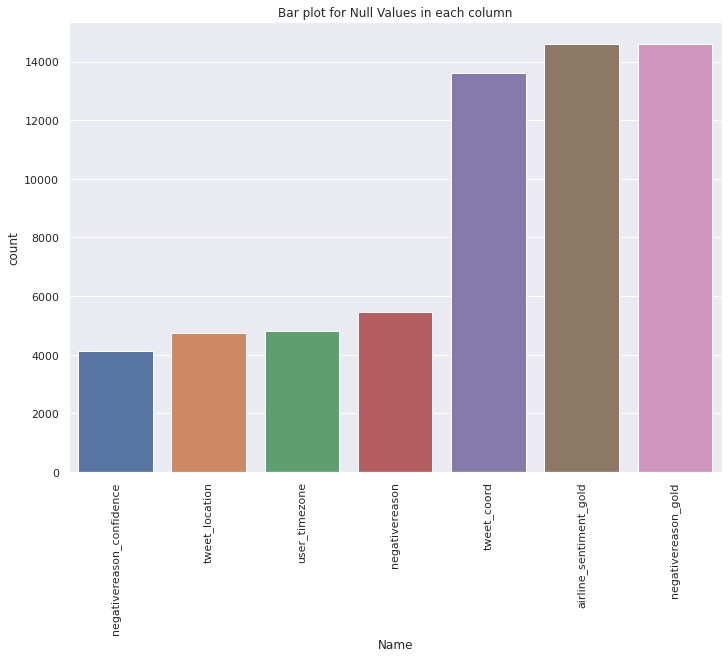

```python
#plotting the count of missing values
plot_missing_values(data)
```

```python
data[data.duplicated()].count()
```

```
tweet_id                        36
airline_sentiment               36
airline_sentiment_confidence    36
negativereason                  19
negativereason_confidence       19
airline                         36
airline_sentiment_gold           0
name                            36
negativereason_gold              0
retweet_count                   36
text                            36
tweet_coord                      4
tweet_created                   36
tweet_location                  26
user_timezone                   30
dtype: int64
```

I do not want to drop duplicates, to account for if a customer flew more than once and left more than one reveiw or multiple customers had the same experience.

```python
unidf = data.nunique()
print(unidf)
```

```
tweet_id                        14485
airline_sentiment                   3
airline_sentiment_confidence     1023
negativereason                     10
negativereason_confidence        1410
airline                             6
airline_sentiment_gold              3
name                             7701
negativereason_gold                13
retweet_count                      18
text                            14427
tweet_coord                       832
tweet_created                   14247
tweet_location                   3081
user_timezone                      85
dtype: int64
```

There are only 10 unique types of negative reasons. Lets list see a list of them.

```python
# checking the names of the columns in the data
print(data.columns)
```

```
Index(['tweet_id', 'airline_sentiment', 'airline_sentiment_confidence',
       'negativereason', 'negativereason_confidence', 'airline',
       'airline_sentiment_gold', 'name', 'negativereason_gold',
       'retweet_count', 'text', 'tweet_coord', 'tweet_created',
       'tweet_location', 'user_timezone'],
      dtype='object')
```

```python
columns = [
    'tweet_id', 'airline_sentiment', 'airline_sentiment_confidence',
       'negativereason', 'negativereason_confidence', 'airline',
       'airline_sentiment_gold', 'name', 'negativereason_gold',
       'retweet_count', 'text', 'tweet_coord', 'tweet_created',
       'tweet_location', 'user_timezone']

# printing the number of occurrences of each unique value in each categorical column
for column in columns:
    print(data[column].value_counts())
    print("-" * 50)
```

```
570290034009636865    2
570305234838429696    2
570299824760860672    2
570300177367633921    2
570300262302289920    2
                     ..
569690786180132865    1
569689297084919808    1
569689184958595072    1
569688749208178688    1
569587140490866689    1
Name: tweet_id, Length: 14485, dtype: int64
--------------------------------------------------
negative    9178
neutral     3099
positive    2363
Name: airline_sentiment, dtype: int64
--------------------------------------------------
1.0000    10445
0.6667       71
0.6632       35
0.6596       30
0.6559       30
          ...
0.3674        1
0.6155        1
0.3708        1
0.6905        1
0.3487        1
Name: airline_sentiment_confidence, Length: 1023, dtype: int64
--------------------------------------------------
Customer Service Issue         2910
Late Flight                    1665
Can't Tell                     1190
Cancelled Flight                847
Lost Luggage                    724
Bad Flight                      580
Flight Booking Problems         529
Flight Attendant Complaints     481
longlines                       178
```

[output cut: 127 more lines]

```
Name: tweet_location, Length: 3081, dtype: int64
--------------------------------------------------
Eastern Time (US & Canada)    3744
Central Time (US & Canada)    1931
Pacific Time (US & Canada)    1208
Quito                          738
Atlantic Time (Canada)         497
                              ...
Warsaw                           1
Bucharest                        1
Wellington                       1
Sarajevo                         1
Saskatchewan                     1
Name: user_timezone, Length: 85, dtype: int64
--------------------------------------------------
```

- Customer service is leading in complaints.

```python
# Let's look at the statistical summary of the data
data.describe(include="all").T
```

|  | count | unique | top | freq | mean | std | min | 25% | 50% | 75% | max |
| --- | --- | --- | --- | --- | --- | --- | --- | --- | --- | --- | --- |
| tweet_id | 14640.0 | NaN | NaN | NaN | 569218351767499200.0 | 779111158481835.875 | 567588278875213824.0 | 568559178101439488.0 | 569477857923110912.0 | 569890473289000960.0 | 570310600460525568.0 |
| airline_sentiment | 14640 | 3 | negative | 9178 | NaN | NaN | NaN | NaN | NaN | NaN | NaN |
| airline_sentiment_confidence | 14640.0 | NaN | NaN | NaN | 0.900169 | 0.16283 | 0.335 | 0.6923 | 1.0 | 1.0 | 1.0 |
| negativereason | 9178 | 10 | Customer Service Issue | 2910 | NaN | NaN | NaN | NaN | NaN | NaN | NaN |
| negativereason_confidence | 10522.0 | NaN | NaN | NaN | 0.638298 | 0.33044 | 0.0 | 0.3606 | 0.6706 | 1.0 | 1.0 |
| airline | 14640 | 6 | United | 3822 | NaN | NaN | NaN | NaN | NaN | NaN | NaN |
| airline_sentiment_gold | 40 | 3 | negative | 32 | NaN | NaN | NaN | NaN | NaN | NaN | NaN |
| name | 14640 | 7701 | JetBlueNews | 63 | NaN | NaN | NaN | NaN | NaN | NaN | NaN |
| negativereason_gold | 32 | 13 | Customer Service Issue | 12 | NaN | NaN | NaN | NaN | NaN | NaN | NaN |
| retweet_count | 14640.0 | NaN | NaN | NaN | 0.08265 | 0.745778 | 0.0 | 0.0 | 0.0 | 0.0 | 44.0 |
| text | 14640 | 14427 | @united thanks | 6 | NaN | NaN | NaN | NaN | NaN | NaN | NaN |
| tweet_coord | 1019 | 832 | [0.0, 0.0] | 164 | NaN | NaN | NaN | NaN | NaN | NaN | NaN |
| tweet_created | 14640 | 14247 | 2015-02-24 09:54:34 -0800 | 5 | NaN | NaN | NaN | NaN | NaN | NaN | NaN |
| tweet_location | 9907 | 3081 | Boston, MA | 157 | NaN | NaN | NaN | NaN | NaN | NaN | NaN |
| user_timezone | 9820 | 85 | Eastern Time (US & Canada) | 3744 | NaN | NaN | NaN | NaN | NaN | NaN | NaN |

#### Vizualizations

[figure not shown]

```python
#plot the distribution of the class label
def bar_plot(data, feature):
    plot = sns.countplot(x =feature, data = data)
    total = len(data)
    for p in plot.patches:
        percentage = '{:.1f}%'.format(200 * p.get_height()/total)
        x = p.get_x() + p.get_width() / 2 - 0.05
        y = p.get_y() + p.get_height()
        plot.annotate(percentage, (x, y),ha="center",
            va="center",
            size=15,
            xytext=(0, 5),
            textcoords="offset points")
    plt.show()

bar_plot(data,'airline_sentiment')
```

- Most tweets about the airlines have a negative sentiment.

```python
# function to create labeled barplots
def labeled_barplot(data, feature,  title, pallet,perc=True, n=None):
    """
    Barplot with percentage at the top

    data: dataframe
    feature: dataframe column
    perc: whether to display percentages instead of count (default is False)
    n: displays the top n category levels (default is None, i.e., display all levels)
    """

    total = len(data[feature])  # length of the column
    count = data[feature].nunique()
    if n is None:
        plt.figure(figsize=(16, 4))
    else:
        plt.figure(figsize=(16, 4))

    plt.xticks(rotation=90, fontsize=15)
    ax = sns.countplot(
        data[feature],
        palette=pallet,
        order=data[feature].value_counts().index[:20],
    )
    ax.set_title('Frequency of {} tweeting about Airlines.format(title)')

    for p in ax.patches:
        if perc == True:
            label = "{:1.2f}%".format(
                100 * p.get_height() / total
            )  # percentage of each class of the category
        else:
            label = p.get_height()  # count of each level of the category

        x = p.get_x() + p.get_width() / 2  # width of the plot
        y = p.get_height()  # height of the plot

        ax.annotate(
            label,
            (x, y),
            ha="center",
            va="center",
            size=12,
            xytext=(0, 5),
            textcoords="offset points",
        )  # annotate the percentage

    plt.show()  # show the plot
```

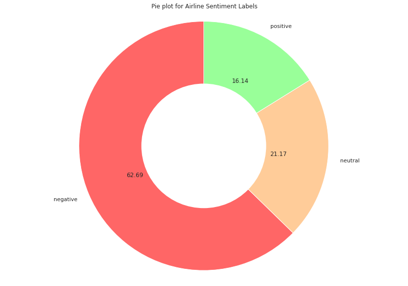

```python
#plot for Airplane Sentiment Labels
#Using matplotlib
colors = ['#ff6666', '#ffcc99', '#99ff99']

sns.set(rc={'figure.figsize':(11.7,8.27)})
plot = plt.pie(data['airline_sentiment'].value_counts(), labels=data['airline_sentiment'].value_counts().index, colors=colors, startangle=90,  autopct='%.2f')
centre_circle = plt.Circle((0,0),0.5,color='black', fc='white',linewidth=0)
fig = plt.gcf()
fig.gca().add_artist(centre_circle)
plt.title('Pie plot for Airline Sentiment Labels')
plt.axis('equal')
plt.tight_layout()
plt.show()
```

- 62% of the airline sentiment is negative.

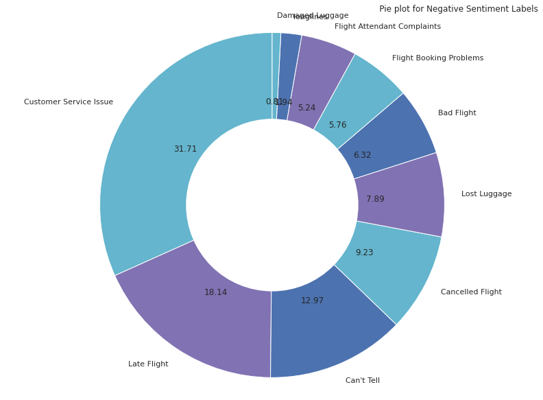

```python
#plot for Negative Sentiment Labels
#Using matplotlib
colors = ['c', 'm', 'b']

sns.set(rc={'figure.figsize':(11.7,8.27)})
plot = plt.pie(data['negativereason'].value_counts(), labels=data['negativereason'].value_counts().index, colors=colors, startangle=90,  autopct='%.2f')
centre_circle = plt.Circle((0,0),0.5,color='black', fc='white',linewidth=0)
fig = plt.gcf()
fig.gca().add_artist(centre_circle)
plt.title('                                                                                                                                             Pie plot for Negative Sentiment Labels')
plt.axis('equal')
plt.tight_layout()
plt.show()
```

- 31% of the negative sentiment is about a customer service issue. With late flights following at 18% and canceled flights at 9%.

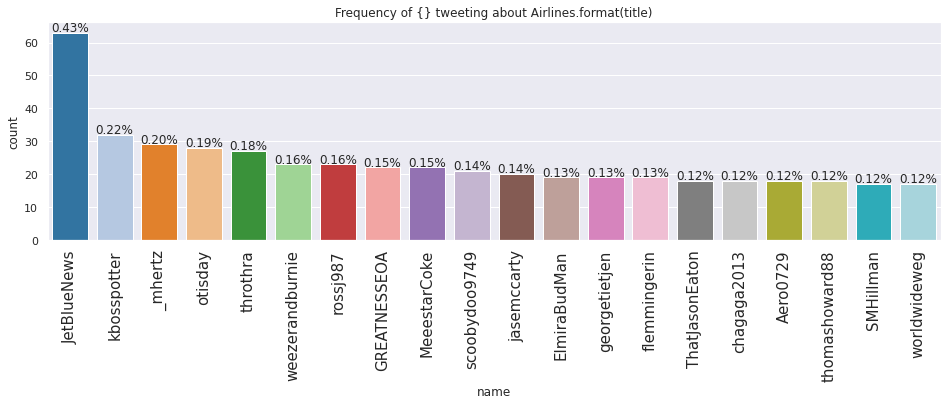

```python
#Visualize the top 20 users by number of tweets
labeled_barplot(data, 'name', 'User Names','tab20')
```

- JetBlueNews is the leading twitter user.

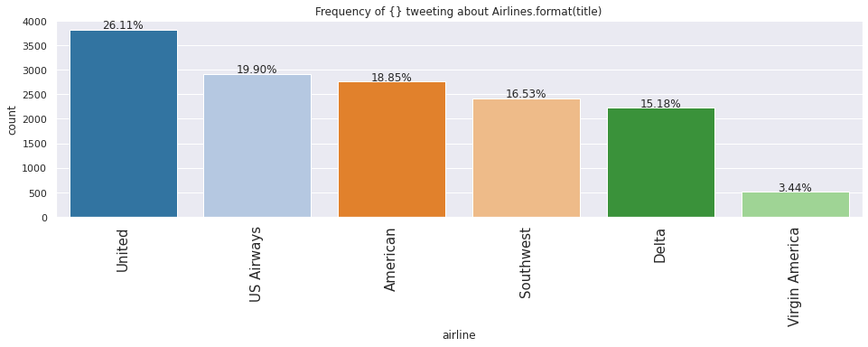

```python
#Top 20 Users location based on the number of tweets¶
labeled_barplot(data, 'airline', 'Tweets Across Airlines', 'tab20')
```

- United has the most tweets

```python
# function to plot stacked bar chart


def stacked_barplot(data, predictor, target):
    """
    Print the category counts and plot a stacked bar chart

    data: dataframe
    predictor: independent variable
    target: target variable
    """
    count = data[predictor].nunique()
    sorter = data[target].value_counts().index[-1]
    tab1 = pd.crosstab(data[predictor], data[target], margins=True).sort_values(
        by=sorter, ascending=False
    )
    print(tab1)
    print("-" * 120)
    tab = pd.crosstab(data[predictor], data[target], normalize="index").sort_values(
        by=sorter, ascending=False
    )
    tab.plot(kind="bar", stacked=True, figsize=(count + 1, 5))
    plt.legend(
        loc="lower left",
        frameon=False,
    )
    plt.legend(loc="upper left", bbox_to_anchor=(1, 1))
    plt.show()
```

```
airline_sentiment  negative  neutral  positive    All
airline
All                    9178     3099      2363  14640
Southwest              1186      664       570   2420
Delta                   955      723       544   2222
United                 2633      697       492   3822
American               1960      463       336   2759
US Airways             2263      381       269   2913
Virgin America          181      171       152    504
------------------------------------------------------------------------------------------------------------------------
```

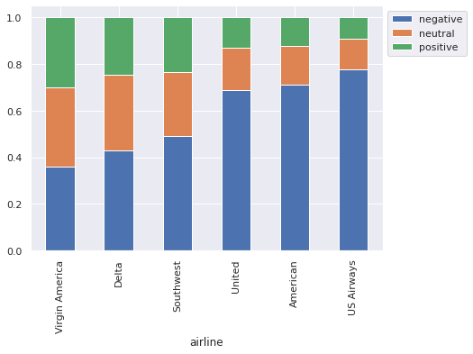

```python
stacked_barplot(data, "airline", "airline_sentiment")
```

- US Airways has the most tweets with negative sentiment.
- Virgian Americia has the most tweets with positive sentiment.

```
negativereason  Bad Flight  Can't Tell  Cancelled Flight  \
airline
All                    580        1190               847
United                 216         379               181
Southwest               90         159               162
American                87         198               246
Delta                   64         186                51
US Airways             104         246               189
Virgin America          19          22                18

negativereason  Customer Service Issue  Damaged Luggage  \
airline
All                               2910               74
United                             681               22
Southwest                          391               14
American                           768               12
Delta                              199               11
US Airways                         811               11
Virgin America                      60                4

negativereason  Flight Attendant Complaints  Flight Booking Problems  \
airline
All                                     481                      529
United                                  168                      144
Southwest                                38                       61
American                                 87                      130
Delta                                    60                       44
US Airways                              123                      122
Virgin America                            5                       28

negativereason  Late Flight  Lost Luggage  longlines   All
airline
All                    1665           724        178  9178
United                  525           269         48  2633
Southwest               152            90         29  1186
American                249           149         34  1960
Delta                   269            57         14   955
US Airways              453           154         50  2263
Virgin America           17             5          3   181
------------------------------------------------------------------------------------------------------------------------
```

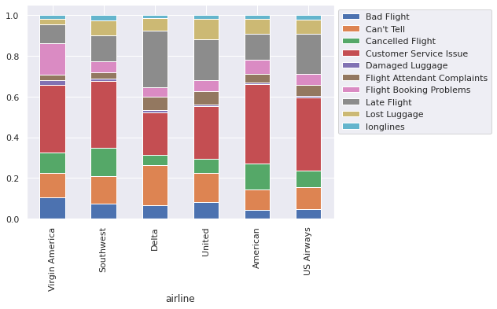

```python
stacked_barplot(data, "airline", "negativereason")
```

- Customer service is shown again to be the leading negative reason.
- Delta has the least custumer service complaints.
- Delta has the most late flights as a negative reason.

```python
# take the top 500 user locations based on no of tweets
dt = data['tweet_location'].value_counts().reset_index()  # get the counts of tweets which contains a fixed no of hashtags
dt.columns = ['tweet_location', 'count']
dt = dt.sort_values(['count'],ascending=False)[:50] #top 50 places
dt.head()
```

|  | tweet_location | count |
| --- | --- | --- |
| 0 | Boston, MA | 157 |
| 1 | New York, NY | 156 |
| 2 | Washington, DC | 150 |
| 3 | New York | 127 |
| 4 | USA | 126 |

- Most Tweets are out of Boston MA
- New York is properly the true lead in tweets because it is listed twice.

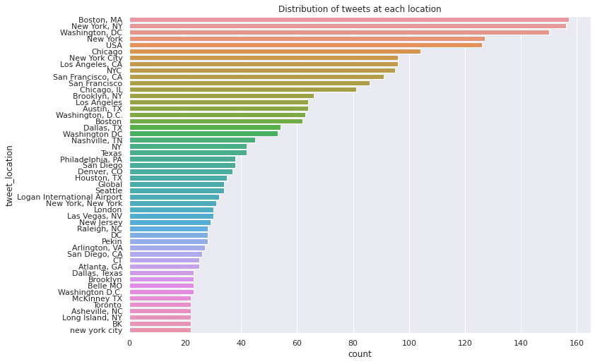

```python
#get the count of tweets from every place
ds = dt.groupby(['tweet_location']).sum().sort_values(by='count', ascending=False).reset_index()
ds = ds[ds["tweet_location"]!="other"]

# get the plot with no of twwets contains x number of tags
dt = ds

fig = sns.barplot(
    x
    =dt["count"],
    y=dt["tweet_location"],
    orientation='horizontal'
).set_title('Distribution of tweets at each location')
```

- Boston MA is also shown to be the lead.

```python
#get the no of words in every text
data['word_count'] = [len(t.split()) for t in data.text]
data.head()
```

|  | tweet_id | airline_sentiment | airline_sentiment_confidence | negativereason | negativereason_confidence | airline | airline_sentiment_gold | name | negativereason_gold | retweet_count | text | tweet_coord | tweet_created | tweet_location | user_timezone | word_count |
| --- | --- | --- | --- | --- | --- | --- | --- | --- | --- | --- | --- | --- | --- | --- | --- | --- |
| 0 | 570306133677760513 | neutral | 1.0000 | NaN | NaN | Virgin America | NaN | cairdin | NaN | 0 | @VirginAmerica What @dhepburn said. | NaN | 2015-02-24 11:35:52 -0800 | NaN | Eastern Time (US & Canada) | 4 |
| 1 | 570301130888122368 | positive | 0.3486 | NaN | 0.0000 | Virgin America | NaN | jnardino | NaN | 0 | @VirginAmerica plus you've added commercials to the experience... tacky. | NaN | 2015-02-24 11:15:59 -0800 | NaN | Pacific Time (US & Canada) | 9 |
| 2 | 570301083672813571 | neutral | 0.6837 | NaN | NaN | Virgin America | NaN | yvonnalynn | NaN | 0 | @VirginAmerica I didn't today... Must mean I need to take another trip! | NaN | 2015-02-24 11:15:48 -0800 | Lets Play | Central Time (US & Canada) | 12 |
| 3 | 570301031407624196 | negative | 1.0000 | Bad Flight | 0.7033 | Virgin America | NaN | jnardino | NaN | 0 | @VirginAmerica it's really aggressive to blast obnoxious "entertainment" in your guests' faces &amp; they have little recourse | NaN | 2015-02-24 11:15:36 -0800 | NaN | Pacific Time (US & Canada) | 17 |
| 4 | 570300817074462722 | negative | 1.0000 | Can't Tell | 1.0000 | Virgin America | NaN | jnardino | NaN | 0 | @VirginAmerica and it's a really big bad thing about it | NaN | 2015-02-24 11:14:45 -0800 | NaN | Pacific Time (US & Canada) | 10 |

#### WordCloud

```python
from wordcloud import WordCloud,STOPWORDS
```

```python
negative_tweets=data[data['airline_sentiment']=='negative']
words = ' '.join(negative_tweets['text'])
cleaned_word = " ".join([word for word in words.split()
                            if 'http' not in word
                                and not word.startswith('@')
                                and word != 'RT'
                            ])
```

```python
wordcloud = WordCloud(stopwords=STOPWORDS,
                      background_color='black',
                      width=3000,
                      height=2500
                     ).generate(cleaned_word)
```

#### Negative WordCloud

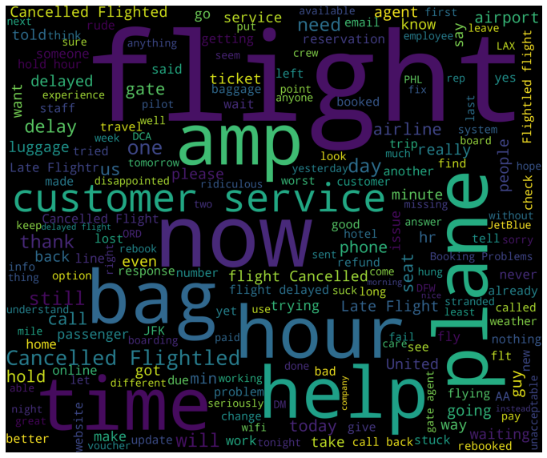

```python
plt.figure(1,figsize=(12, 12))
plt.imshow(wordcloud)
plt.axis('off')
plt.show()
```

- The word cloud highlights that customer service is a cheif complaint.
- Help is seen in the word cloud. This likly means alot of negative tweets have requests for help.
- There are a few phrases that mean a delayed flight in this word cloud.
- Canceled flight is present in the word cloud.

#### Positive WordCloud setup.

```python
positive_tweets=data[data['airline_sentiment']=='positive']
words = ' '.join(positive_tweets['text'])
cleaned_word = " ".join([word for word in words.split()
                            if 'http' not in word
                                and not word.startswith('@')
                                and word != 'RT'
                            ])
```

```python
wordcloud = WordCloud(stopwords=STOPWORDS,
                      background_color='black',
                      width=3000,
                      height=2500
                     ).generate(cleaned_word)
```

#### Posititive WordCloud

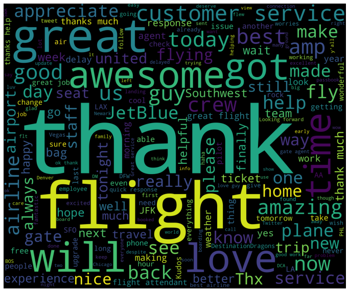

```python
plt.figure(1,figsize=(12, 12))
plt.imshow(wordcloud)
plt.axis('off')
plt.show()
```

- This word cloud expresses graditude for good customer service.

### Summary of EDA

Most tweets among the airlines are negative. Customer service is the leading negative reason in the tweets. United is the most tweeted about. US Airways has the most negative tweets. All airlines have customer service issues. Delta has the least customer service issues and the most delay issues.

### Pre-Processing

```python
data = data[["text","airline_sentiment"]]
```

```python
pd.set_option('display.max_colwidth', None) # Display full dataframe information (Non-turncated Text column.)

data.head()                                 # Check first 5 rows of data
```

|  | text | airline_sentiment |
| --- | --- | --- |
| 0 | @VirginAmerica What @dhepburn said. | neutral |
| 1 | @VirginAmerica plus you've added commercials to the experience... tacky. | positive |
| 2 | @VirginAmerica I didn't today... Must mean I need to take another trip! | neutral |
| 3 | @VirginAmerica it's really aggressive to blast obnoxious "entertainment" in your guests' faces &amp; they have little recourse | negative |
| 4 | @VirginAmerica and it's a really big bad thing about it | negative |

#### a. Html tag removal.

```python
#remove the html tags
def strip_html(text):
    soup = BeautifulSoup(text, "html.parser")
    return soup.get_text()

#expand the contractions
def replace_contractions(text):
    """Replace contractions in string of text"""
    return contractions.fix(text)

#remove the numericals present in the text
def remove_numbers(text):
  text = re.sub(r'\d+', '', text)
  return text

# remove the url's present in the text
def remove_url(text):
    text = re.sub('http[s]?://(?:[a-zA-Z]|[0-9]|[$-_@.&+]|[!*\(\),]|(?:%[0-9a-fA-F][0-9a-fA-F]))+','',text)
    return text

# remove the mentions in the tweets
def remove_mention(text):
    text = re.sub(r'@\w+','',text)
    return text

def clean_text(text):
    text = strip_html(text)
    text = replace_contractions(text)
    text = remove_numbers(text)
    text = remove_url(text)
    text = remove_mention(text)
    return text
data['text'] = data['text'].apply(lambda x: clean_text(x))
data.head()
```

|  | text | airline_sentiment |
| --- | --- | --- |
| 0 | What said. | neutral |
| 1 | plus you have added commercials to the experience... tacky. | positive |
| 2 | I did not today... Must mean I need to take another trip! | neutral |
| 3 | it is really aggressive to blast obnoxious "entertainment" in your guests' faces & they have little recourse | negative |
| 4 | and it is a really big bad thing about it | negative |

b. Tokenization.

```python
data['text'] = data.apply(lambda row: nltk.word_tokenize(row['text']), axis=1) # Tokenization of data
data.head()
```

|  | text | airline_sentiment |
| --- | --- | --- |
| 0 | [What, said, .] | neutral |
| 1 | [plus, you, have, added, commercials, to, the, experience, ..., tacky, .] | positive |
| 2 | [I, did, not, today, ..., Must, mean, I, need, to, take, another, trip, !] | neutral |
| 3 | [it, is, really, aggressive, to, blast, obnoxious, ``, entertainment, '', in, your, guests, ', faces, &, they, have, little, recourse] | negative |
| 4 | [and, it, is, a, really, big, bad, thing, about, it] | negative |

c. Remove the numbers.

```python
#remove the numericals present in the text
def remove_numbers(text):
  text = re.sub(r'\d+', '', text)
  return text
```

```python
#remove the numericals present in the text
def remove_numbers(text):
  text = re.sub(r'\d+', '', text)
  return text
```

```python
data.head()
```

|  | text | airline_sentiment |
| --- | --- | --- |
| 0 | [What, said, .] | neutral |
| 1 | [plus, you, have, added, commercials, to, the, experience, ..., tacky, .] | positive |
| 2 | [I, did, not, today, ..., Must, mean, I, need, to, take, another, trip, !] | neutral |
| 3 | [it, is, really, aggressive, to, blast, obnoxious, ``, entertainment, '', in, your, guests, ', faces, &, they, have, little, recourse] | negative |
| 4 | [and, it, is, a, really, big, bad, thing, about, it] | negative |

```python
data.head()
```

|  | text | airline_sentiment |
| --- | --- | --- |
| 0 | [What, said, .] | neutral |
| 1 | [plus, you, have, added, commercials, to, the, experience, ..., tacky, .] | positive |
| 2 | [I, did, not, today, ..., Must, mean, I, need, to, take, another, trip, !] | neutral |
| 3 | [it, is, really, aggressive, to, blast, obnoxious, ``, entertainment, '', in, your, guests, ', faces, &, they, have, little, recourse] | negative |
| 4 | [and, it, is, a, really, big, bad, thing, about, it] | negative |

```python
# remove the url's present in the text
def remove_url(text):
    text = re.sub('http[s]?://(?:[a-zA-Z]|[0-9]|[$-_@.&+]|[!*\(\),]|(?:%[0-9a-fA-F][0-9a-fA-F]))+','',text)
    return text
```

```python
data.head()
```

|  | text | airline_sentiment |
| --- | --- | --- |
| 0 | [What, said, .] | neutral |
| 1 | [plus, you, have, added, commercials, to, the, experience, ..., tacky, .] | positive |
| 2 | [I, did, not, today, ..., Must, mean, I, need, to, take, another, trip, !] | neutral |
| 3 | [it, is, really, aggressive, to, blast, obnoxious, ``, entertainment, '', in, your, guests, ', faces, &, they, have, little, recourse] | negative |
| 4 | [and, it, is, a, really, big, bad, thing, about, it] | negative |

d. Removal of Special Characters and Punctuations.

```python
# remove the mentions in the tweets
def remove_mention(reveiw):
    review = re.sub(r'@\w+','',text)
    return review
```

```python
# Remove the punctuations
def remove_punctuation(words):
    """Remove punctuation from list of tokenized words"""
    new_words = []
    for word in words:
        new_word = re.sub(r'[^\w\s]', '', word)
        if new_word != '':
            new_words.append(new_word)
    return new_words
```

```python
data.head()
```

|  | text | airline_sentiment |
| --- | --- | --- |
| 0 | [What, said, .] | neutral |
| 1 | [plus, you, have, added, commercials, to, the, experience, ..., tacky, .] | positive |
| 2 | [I, did, not, today, ..., Must, mean, I, need, to, take, another, trip, !] | neutral |
| 3 | [it, is, really, aggressive, to, blast, obnoxious, ``, entertainment, '', in, your, guests, ', faces, &, they, have, little, recourse] | negative |
| 4 | [and, it, is, a, really, big, bad, thing, about, it] | negative |

e. Removal of stopwords

```python
import nltk
nltk.download('stopwords')
```

```
True
```

```python
data.head()
```

|  | text | airline_sentiment |
| --- | --- | --- |
| 0 | [What, said, .] | neutral |
| 1 | [plus, you, have, added, commercials, to, the, experience, ..., tacky, .] | positive |
| 2 | [I, did, not, today, ..., Must, mean, I, need, to, take, another, trip, !] | neutral |
| 3 | [it, is, really, aggressive, to, blast, obnoxious, ``, entertainment, '', in, your, guests, ', faces, &, they, have, little, recourse] | negative |
| 4 | [and, it, is, a, really, big, bad, thing, about, it] | negative |

f. Conversion to lowercase.

```python
# convert all characters to lowercase
def to_lowercase(words):
    """Convert all characters to lowercase from list of tokenized words"""
    new_words = []
    for word in words:
        new_word = word.lower()
        new_words.append(new_word)
    return new_words
```

```python
data.head()
```

|  | text | airline_sentiment |
| --- | --- | --- |
| 0 | [What, said, .] | neutral |
| 1 | [plus, you, have, added, commercials, to, the, experience, ..., tacky, .] | positive |
| 2 | [I, did, not, today, ..., Must, mean, I, need, to, take, another, trip, !] | neutral |
| 3 | [it, is, really, aggressive, to, blast, obnoxious, ``, entertainment, '', in, your, guests, ', faces, &, they, have, little, recourse] | negative |
| 4 | [and, it, is, a, really, big, bad, thing, about, it] | negative |

g. Lemmatize or stemming.

```python
def lemmatize_list(words):
    new_words = []
    for word in words:
      new_words.append(lemmatizer.lemmatize(word, pos='v'))
    return new_words
```

```python
data.head()
```

|  | text | airline_sentiment |
| --- | --- | --- |
| 0 | [What, said, .] | neutral |
| 1 | [plus, you, have, added, commercials, to, the, experience, ..., tacky, .] | positive |
| 2 | [I, did, not, today, ..., Must, mean, I, need, to, take, another, trip, !] | neutral |
| 3 | [it, is, really, aggressive, to, blast, obnoxious, ``, entertainment, '', in, your, guests, ', faces, &, they, have, little, recourse] | negative |
| 4 | [and, it, is, a, really, big, bad, thing, about, it] | negative |

h. Join the words in the list to convert back to text string in the data frame. (So that each row contains the data in text format.)

```python
data.text
```

```
0                                                                                                                                                       [What, said, .]
1                                                                                             [plus, you, have, added, commercials, to, the, experience, ..., tacky, .]
2                                                                                            [I, did, not, today, ..., Must, mean, I, need, to, take, another, trip, !]
3                                [it, is, really, aggressive, to, blast, obnoxious, ``, entertainment, '', in, your, guests, ', faces, &, they, have, little, recourse]
4                                                                                                                  [and, it, is, a, really, big, bad, thing, about, it]
                                                                                      ...
14635                                                                                                   [thank, you, we, got, on, a, different, flight, to, Chicago, .]
14636    [leaving, over, minutes, Late, Flight, ., No, warnings, or, communication, until, we, were, minutes, Late, Flight, ., That, is, called, shitty, customer, svc]
14637                                                                                                            [Please, bring, American, Airlines, to, #, BlackBerry]
14638     [you, have, my, money, ,, you, change, my, flight, ,, and, do, not, answer, your, phones, !, Any, other, suggestions, so, I, can, make, my, commitment, ?, ?]
14639         [we, have, people, so, we, need, know, how, many, seats, are, on, the, next, flight, ., Plz, put, us, on, standby, for, people, on, the, next, flight, ?]
Name: text, Length: 14640, dtype: object
```

```python
# joining with ","
data["text"]= data["text"].str.join(",")
```

i. Print the first 5 rows of data after pre-processing.

```python
data.head()
```

|  | text | airline_sentiment |
| --- | --- | --- |
| 0 | What,said,. | neutral |
| 1 | plus,you,have,added,commercials,to,the,experience,...,tacky,. | positive |
| 2 | I,did,not,today,...,Must,mean,I,need,to,take,another,trip,! | neutral |
| 3 | it,is,really,aggressive,to,blast,obnoxious,``,entertainment,'',in,your,guests,',faces,&,they,have,little,recourse | negative |
| 4 | and,it,is,a,really,big,bad,thing,about,it | negative |

### Vectorization

- Apply count vectorizer, Tf-IDF vectorizer, on the required text column to make it suitable for fitting the model

a. Use CountVectorizer.

```python
# Vectorization (Convert text data to numbers).
from sklearn.feature_extraction.text import CountVectorizer

Count_vec = CountVectorizer(max_features=500)                # Keep only 500 features as number of features will increase the processing time.
data_features = Count_vec.fit_transform(data['text'])

data_features = data_features.toarray()                        # Convert the data features to array.
```

```python
data_features.shape       #Shape of the feature vector
```

```
(14640, 500)
```

b. Use TfidfVectorizer.

```python
#from sklearn.feature_extraction.text import TfidfVectorizer
# list of text documents
text = data['text']
# create the transform
vectorizer = TfidfVectorizer()
# tokenize and build vocab
vectorizer.fit(text)
# summarize
print(vectorizer.vocabulary_)
print(vectorizer.idf_)
# encode document
vector = vectorizer.transform([text[0]])
# summarize encoded vector
print(vector.shape)
print(vector.toarray())
```

```
{'what': 10755, 'said': 8374, 'plus': 7303, 'you': 11055, 'have': 4349, 'added': 127, 'commercials': 1889, 'to': 9885, 'the': 9719, 'experience': 3335, 'tacky': 9540, 'did': 2615, 'not': 6588, 'today': 9888, 'must': 6301, 'mean': 5938, 'need': 6381, 'take': 9556, 'another': 443, 'trip': 10055, 'it':…
[9.89843391 4.99686971 9.89843391 ... 9.89843391 9.89843391 8.79982162]
(1, 11115)
[[0. 0. 0. ... 0. 0. 0.]]
```

```python
data.shape
```

```
(14640, 2)
```

### Build Model

```python
X = data_features

y = data.airline_sentiment
```

```python
data.airline_sentiment.shape
```

```
(14640,)
```

```python
data_features.shape
```

```
(14640, 500)
```

```python
# Split data into training and testing set.

from sklearn.model_selection import train_test_split

X_train, X_test, y_train, y_test = train_test_split(X, y, test_size=0.25, shuffle=False)
```

```python
# Finding optimal number of base learners using k-fold CV ->
base_ln = np.arange(100,400,100).tolist()
base_ln
```

```
[100, 200, 300]
```

```python
# K-Fold Cross - validation .
cv_scores = []
for b in base_ln:
    clf = RandomForestClassifier(n_estimators = b)
    scores = cross_val_score(clf, X_train, y_train, cv = 5, scoring = 'accuracy')
    cv_scores.append(scores.mean())
```

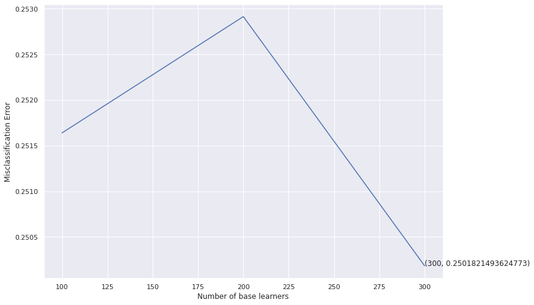

```python
# plotting the error as k increases
error = [1 - x for x in cv_scores]                                 #error corresponds to each nu of estimator
optimal_learners = base_ln[error.index(min(error))]                #Selection of optimal nu of n_estimator corresponds to minimum error.
plt.plot(base_ln, error)                                           #Plot between each nu of estimator and misclassification error
xy = (optimal_learners, min(error))
plt.annotate('(%s, %s)' % xy, xy = xy, textcoords='data')
plt.xlabel("Number of base learners")
plt.ylabel("Misclassification Error")
plt.show()
```

```python
# Training the best model and calculating accuracy on test data .
clf = RandomForestClassifier(n_estimators = optimal_learners)
clf.fit(X_train, y_train)
clf.score(X_test, y_test)
count_vectorizer_predicted = clf.predict(X_test)
print(classification_report(y_test ,count_vectorizer_predicted , target_names = ['0' , '2',  '3']))
print("Accuracy of the model is : ",accuracy_score(y_test,count_vectorizer_predicted))
```

```
              precision    recall  f1-score   support

           0       0.84      0.93      0.88      2627
           2       0.59      0.37      0.46       577
           3       0.70      0.61      0.65       456

    accuracy                           0.80      3660
   macro avg       0.71      0.64      0.66      3660
weighted avg       0.78      0.80      0.79      3660

Accuracy of the model is :  0.8019125683060109
```

- The accuracy is above the target value of more than or equal to 0.75.

```
[[2446  109   72]
 [ 318  213   46]
 [ 144   36  276]]
```

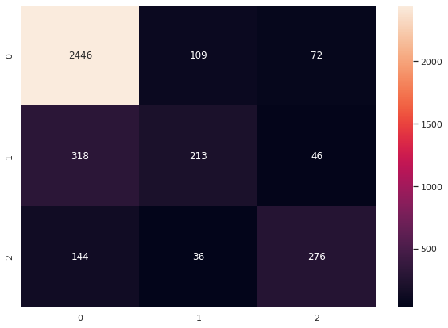

```python
# Print and plot Confusion matirx to get an idea of how the distribution of the prediction is, among all the classes.

import matplotlib.pyplot as plt
import seaborn as sns
from sklearn.metrics import confusion_matrix

conf_mat = confusion_matrix(y_test, count_vectorizer_predicted)

print(conf_mat)

df_cm = pd.DataFrame(conf_mat, index = [i for i in ['0', '1', '2']],
                  columns = [i for i in ['0', '1','2']])
plt.figure(figsize = (10,7))
sns.heatmap(df_cm, annot=True, fmt='g')
```

```
thanks,thank,not,no,great,to,the,you,is,and,your,for,flight,on,my,love,can,in,it,delayed,of,hours,awesome,have,hold,was,that,do,me,but,cancelled,why,are,best,with,hour,this,at,now,amazing,
```

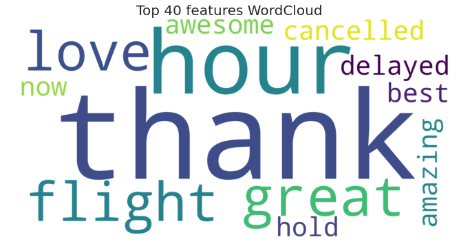

```python
all_features = Count_vec.get_feature_names()              #Instantiate the feature from the vectorizer
top_features=''                                            # Addition of top 40 feature into top_feature after training the model
feat=clf.feature_importances_
features=np.argsort(feat)[::-1]
for i in features[0:40]:
    top_features+=all_features[i]
    top_features+=','

print(top_features)

print(" ")
print(" ")

from wordcloud import WordCloud
wordcloud = WordCloud(background_color="white",colormap='viridis',width=2000,
                          height=1000).generate(top_features)

# Display the generated image:
plt.imshow(wordcloud, interpolation='bilinear')
plt.figure(1, figsize=(14, 11), frameon='equal')
plt.title('Top 40 features WordCloud', fontsize=20)
plt.axis("off")
plt.show()
```

### Tfidf: Less importance to common words

```python
# Using TfidfVectorizer to convert text data to numbers.

from sklearn.feature_extraction.text import TfidfVectorizer

tfidf_vect = TfidfVectorizer(max_features=500)
data_features = tfidf_vect.fit_transform(data['text'])

data_features = data_features.toarray()

data_features.shape     #feature shape
```

```
(14640, 500)
```

```python
X = data_features

y = data.airline_sentiment
```

```python
# Split data into training and testing set.

from sklearn.model_selection import train_test_split

X_train, X_test, y_train, y_test = train_test_split(X, y, test_size=0.25, shuffle=False)
```

```python
# Finding optimal number of base learners using k-fold CV ->
base_ln = np.arange(100,400,100).tolist()
base_ln
```

```
[100, 200, 300]
```

```python
# K-Fold Cross - validation .
cv_scores = []
for b in base_ln:
    clf = RandomForestClassifier(n_estimators = b)
    scores = cross_val_score(clf, X_train, y_train, cv = 5, scoring = 'accuracy')
    cv_scores.append(scores.mean())
```

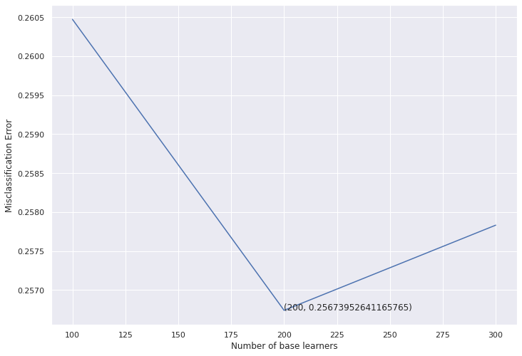

```python
# plotting the error as k increases
error = [1 - x for x in cv_scores]                                 #error corresponds to each nu of estimator
optimal_learners = base_ln[error.index(min(error))]                #Selection of optimal nu of n_estimator corresponds to minimum error.
plt.plot(base_ln, error)                                           #Plot between each nu of estimator and misclassification error
xy = (optimal_learners, min(error))
plt.annotate('(%s, %s)' % xy, xy = xy, textcoords='data')
plt.xlabel("Number of base learners")
plt.ylabel("Misclassification Error")
plt.show()
```

- After 200 base learners the error increases slowly.

```python
# Training the best model and calculating accuracy on test data .
clf = RandomForestClassifier(n_estimators = optimal_learners)
clf.fit(X_train, y_train)
clf.score(X_test, y_test)
tf_idf_predicted = clf.predict(X_test)
print(classification_report(y_test , tf_idf_predicted , target_names = ['0' , '1', '2']))
print("Accuracy of the model is : ",accuracy_score(y_test,tf_idf_predicted))
```

```
              precision    recall  f1-score   support

           0       0.83      0.94      0.88      2627
           1       0.60      0.35      0.44       577
           2       0.74      0.57      0.64       456

    accuracy                           0.80      3660
   macro avg       0.72      0.62      0.66      3660
weighted avg       0.78      0.80      0.79      3660

Accuracy of the model is :  0.8027322404371585
```

- This model meets the target accuracy.

```
[[2473  102   52]
 [ 331  204   42]
 [ 160   35  261]]
```

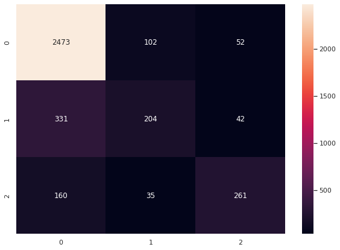

```python
# Print and plot Confusion matirx to get an idea of how the distribution of the prediction is, among all the classes.

import matplotlib.pyplot as plt
import seaborn as sns
from sklearn.metrics import confusion_matrix

conf_mat = confusion_matrix(y_test, tf_idf_predicted)

print(conf_mat)

df_cm = pd.DataFrame(conf_mat, index = [i for i in ['0', '1', '2']],
                  columns = [i for i in ['0', '1', '2']])
plt.figure(figsize = (10,7))
sns.heatmap(df_cm, annot=True, fmt='g')
```

```
thanks, thank, not, you, to, great, no, the, is, and, on, for, flight, can, my, love, your, in, it, do, was, have, of, that, from, awesome, me, but, hours, will, with, hold, delayed, cancelled, are, best, this, now, any, at,
```

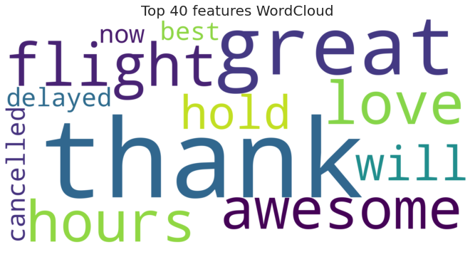

```python
all_features = tfidf_vect.get_feature_names()              #Instantiate the feature from the vectorizer
top_features=''                                            # Addition of top 40 feature into top_feature after training the model
feat=clf.feature_importances_
features=np.argsort(feat)[::-1]
for i in features[0:40]:
    top_features+=all_features[i]
    top_features+=', '

print(top_features)

print(" ")
print(" ")

from wordcloud import WordCloud
wordcloud = WordCloud(background_color="white",colormap='viridis',width=2000,
                          height=1000).generate(top_features)

# Display the generated image:
plt.imshow(wordcloud, interpolation='bilinear')
plt.figure(1, figsize=(14, 11), frameon='equal')
plt.title('Top 40 features WordCloud', fontsize=20)
plt.axis("off")
plt.show()
```

```python
#convert the test samples into a dataframe where the columns are
#the y_test(ground truth labels),tf-idf model predicted labels(tf_idf_predicted),Count Vectorizer model predicted labels(count_vectorizer_predicted)
df = pd.DataFrame(y_test.tolist(),columns =['y_test'])
df['count_vectorizer_predicted'] = count_vectorizer_predicted
df['tf_idf_predicted'] = tf_idf_predicted
df.head()
```

|  | y_test | count_vectorizer_predicted | tf_idf_predicted |
| --- | --- | --- | --- |
| 0 | negative | negative | negative |
| 1 | negative | negative | negative |
| 2 | negative | negative | negative |
| 3 | negative | negative | negative |
| 4 | positive | negative | negative |

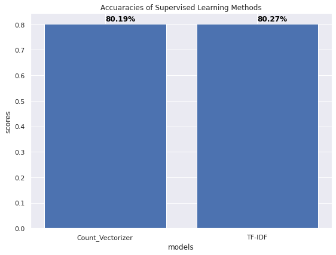

```python
#create bar plot to compare the accuaracies of Count Vectorizer and TF-IDF
import matplotlib.pyplot as plt
fig = plt.figure(figsize=(7,5))
ax = fig.add_axes([0,0,1,1])
subjects = ['Count_Vectorizer', 'TF-IDF']

# calculation accuracies of Count Vectorizer and TF-IDF using accuracy_score metrics
scores = [accuracy_score(y_test,count_vectorizer_predicted),accuracy_score(y_test,tf_idf_predicted)]
ax.bar(subjects,scores)
ax.set_ylabel('scores',fontsize= 12)    # y axis label
ax.set_xlabel('models',fontsize= 12)    # x axis label
ax.set_title('Accuaracies of Supervised Learning Methods')  # tittle
for i, v in enumerate(scores):
    ax.text( i ,v+0.01, '{:.2f}%'.format(100*v), color='black', fontweight='bold')
    plt.savefig('barplot_1.png',dpi=100, format='png', bbox_inches='tight')
plt.show()
```

- TF-IDF performed alot better than count_vectorizer the first time the notebook was ran. The final time the notebook ran they are almost tied.

### Conclusion:

If I had to choose to use only one vectorizer it would be TF-IDE because it outperformed count vectorizer on the first time. Both vectorizers provided models with accuracies above the target value of 75%, so both of them are good choices.

#### Key findings:

Every airline should invest in better customer service training given that poor customer service agents were cited across the board. Delta, in particular, should also invest in better flight scheduling software because late flights were the primary customer complaint for this airline.

Saving file

```python
%shell jupyter nbconvert --to html /content/NLPAirlineTwitterJBasen.ipynb
```

```
[NbConvertApp] Converting notebook /content/NLPAirlineTwitterJBasen.ipynb to html
[NbConvertApp] Writing 2355470 bytes to /content/NLPAirlineTwitterJBasen.html
```